# Simulatie lineaire regressie

## Wat is het model?

Het statistische model bij jullie experiment is:

$$\text{Abs} = a + b \cdot \text{Conc} + \varepsilon$$

We nemen aan dat $\varepsilon$ normaal verdeeld is met gemiddelde 0 en standaarddeviatie (SD) 1.

Met `set.seed()` krijg je bij elke run dezelfde toevalsgetallen:

```r
set.seed(222)
```

Eerst maken we de concentraties `Conc`:

```r
Conc <- c(0, 1, 2, 3, 4, 5, 6)
n <- length(Conc)
```

Dan kiezen we het intercept `a` en de richtingscoëfficiënt `b`:

```r
a <- 0
b <- 3
```

Dan maken we eerst het deterministische model en plotten we dat:

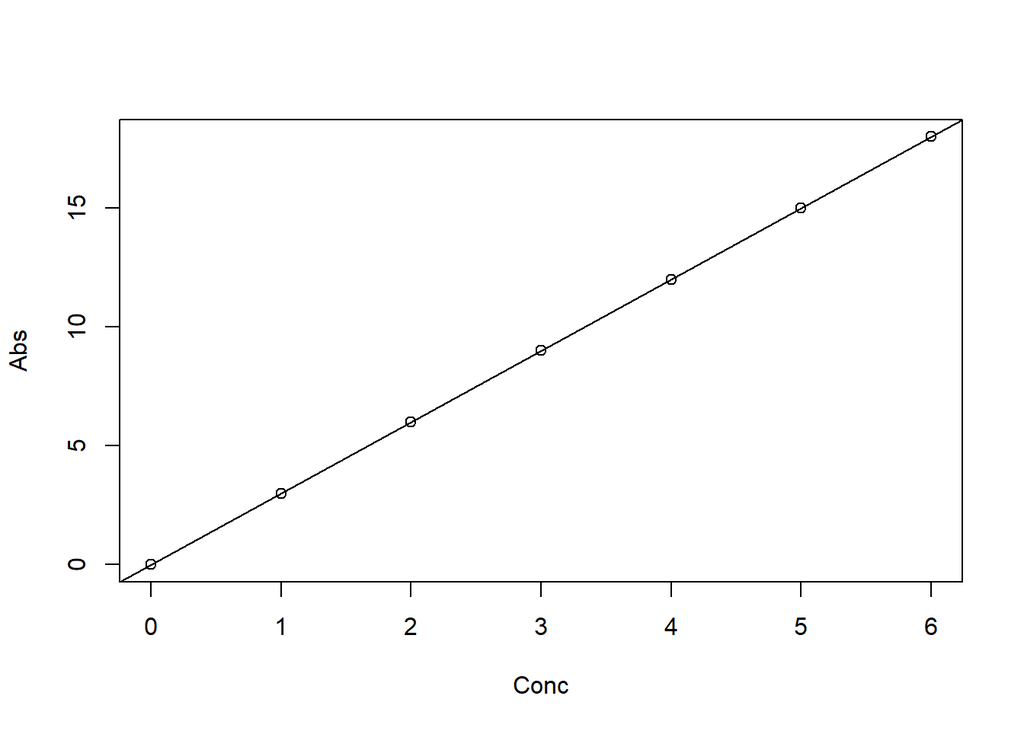

```r
Abs <- a + b * Conc
plot(Abs ~ Conc)
abline(a, b)
```

Alle punten liggen op de lijn. Nu voegen we spreiding toe aan de data. Daarvoor maken we eerst $\varepsilon$:

```r
Epsilon <- rnorm(n = n, mean = 0, sd = 1)
print(Epsilon)
```

```
[1]  1.487757090 -0.001891901  1.381020790 -0.380213631  0.184136230
[6] -0.246895883 -1.215560910
```

### Interlude: variantie

De spreiding van `Epsilon` meten we met de variantie: de som van de kwadraten rond het gemiddelde, gedeeld door $n - 1$:

$$s^2 = \frac{\sum_{i=1}^{n} (\varepsilon_i - \bar{\varepsilon})^2}{n - 1}$$

In R wordt dat:

```r
sum((Epsilon - mean(Epsilon))^2)
```

```
[1] 5.62907
```

```r
Variantie <- sum((Epsilon - mean(Epsilon))^2) / (n - 1)
Variantie
```

```
[1] 0.9381783
```

```r
var(Epsilon)
```

```
[1] 0.9381783
```

```r
sqrt(var(Epsilon))
```

```
[1] 0.9685961
```

```r
sd(Epsilon)
```

```
[1] 0.9685961
```

Nu simuleren we het hele model:

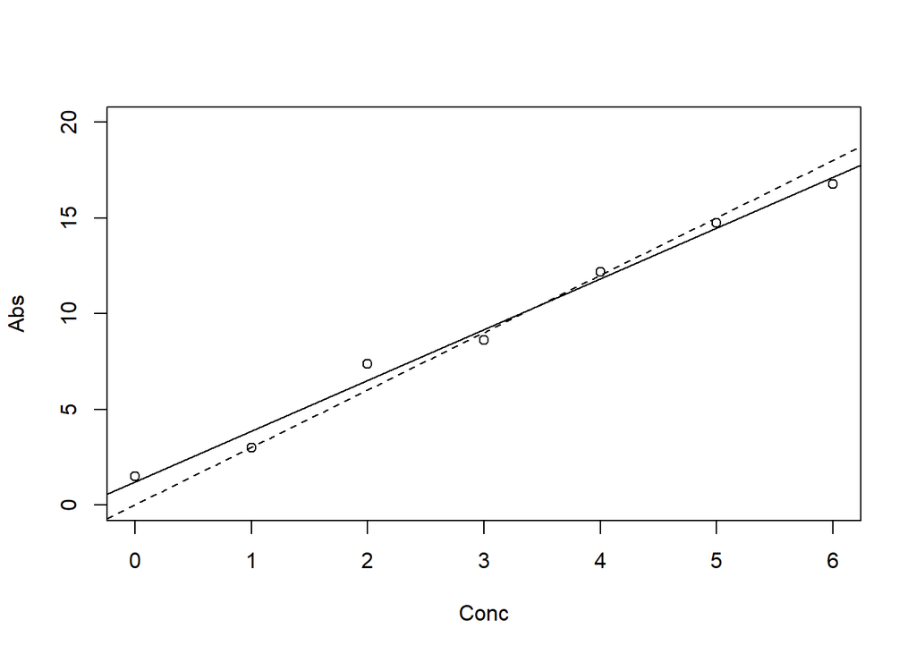

```r
Abs <- a + b * Conc + Epsilon
plot(Abs ~ Conc, ylim =c(0,20))
abline(a, b, lty = 2)
abline(lm(Abs ~ Conc), lty = 1)
```

De gestippelde lijn is de echte lijn, de doorgetrokken lijn de geschatte. Nu kunnen we er een statistische analyse op loslaten:

```r
Model <- lm(Abs ~ Conc)
summary(Model)
```

```
Call:
lm(formula = Abs ~ Conc)

Residuals:
      1       2       3       4       5       6       7
 0.2655 -0.8743  0.8585 -0.5528  0.3614  0.2803 -0.3385

Coefficients:
            Estimate Std. Error t value Pr(>|t|)
(Intercept)   1.2223     0.4521   2.704   0.0426 *
Conc          2.6501     0.1254  21.134  4.4e-06 ***
---
Signif. codes:  0 '***' 0.001 '**' 0.01 '*' 0.05 '.' 0.1 ' ' 1

Residual standard error: 0.6635 on 5 degrees of freedom
Multiple R-squared:  0.9889,    Adjusted R-squared:  0.9867
F-statistic: 446.7 on 1 and 5 DF,  p-value: 4.395e-06
```

Wat is de model-matrix, coëfficiëntenvector, en het product?

```r
Model_Matrix <- model.matrix(Model)
Parameters <- c(a,b)
Model_Matrix %*% (Parameters)
```

```
  [,1]
1    0
2    3
3    6
4    9
5   12
6   15
7   18
```

Wat zit er in `Model`?

```r
str(Model)
```

```
List of 12
 $ coefficients : Named num [1:2] 1.22 2.65
  ..- attr(*, "names")= chr [1:2] "(Intercept)" "Conc"
 $ residuals    : Named num [1:7] 0.265 -0.874 0.859 -0.553 0.361 ...
  ..- attr(*, "names")= chr [1:7] "1" "2" "3" "4" ...
 $ effects      : Named num [1:7] -24.2685 14.0231 0.8116 -0.7461 0.0217 ...
  ..- attr(*, "names")= chr [1:7] "(Intercept)" "Conc" "" "" ...
 $ rank         : int 2
 $ fitted.values: Named num [1:7] 1.22 3.87 6.52 9.17 11.82 ...
  ..- attr(*, "names")= chr [1:7] "1" "2" "3" "4" ...
 $ assign       : int [1:2] 0 1
 $ qr           :List of 5
  ..$ qr   : num [1:7, 1:2] -2.646 0.378 0.378 0.378 0.378 ...
  .. ..- attr(*, "dimnames")=List of 2
  .. .. ..$ : chr [1:7] "1" "2" "3" "4" ...
  .. .. ..$ : chr [1:2] "(Intercept)" "Conc"
  .. ..- attr(*, "assign")= int [1:2] 0 1
  ..$ qraux: num [1:2] 1.38 1.22
  ..$ pivot: int [1:2] 1 2
  ..$ tol  : num 1e-07
  ..$ rank : int 2
  ..- attr(*, "class")= chr "qr"
 $ df.residual  : int 5
 $ xlevels      : Named list()
 $ call         : language lm(formula = Abs ~ Conc)
 $ terms        :Classes 'terms', 'formula'  language Abs ~ Conc
  .. ..- attr(*, "variables")= language list(Abs, Conc)
  .. ..- attr(*, "factors")= int [1:2, 1] 0 1
  .. .. ..- attr(*, "dimnames")=List of 2
  .. .. .. ..$ : chr [1:2] "Abs" "Conc"
  .. .. .. ..$ : chr "Conc"
  .. ..- attr(*, "term.labels")= chr "Conc"
  .. ..- attr(*, "order")= int 1
  .. ..- attr(*, "intercept")= int 1
  .. ..- attr(*, "response")= int 1
  .. ..- attr(*, ".Environment")=<environment: R_GlobalEnv>
  .. ..- attr(*, "predvars")= language list(Abs, Conc)
  .. ..- attr(*, "dataClasses")= Named chr [1:2] "numeric" "numeric"
  .. .. ..- attr(*, "names")= chr [1:2] "Abs" "Conc"
 $ model        :'data.frame':  7 obs. of  2 variables:
  ..$ Abs : num [1:7] 1.49 3 7.38 8.62 12.18 ...
  ..$ Conc: num [1:7] 0 1 2 3 4 5 6
  ..- attr(*, "terms")=Classes 'terms', 'formula'  language Abs ~ Conc
  .. .. ..- attr(*, "variables")= language list(Abs, Conc)
  .. .. ..- attr(*, "factors")= int [1:2, 1] 0 1
  .. .. .. ..- attr(*, "dimnames")=List of 2
  .. .. .. .. ..$ : chr [1:2] "Abs" "Conc"
  .. .. .. .. ..$ : chr "Conc"
  .. .. ..- attr(*, "term.labels")= chr "Conc"
  .. .. ..- attr(*, "order")= int 1
  .. .. ..- attr(*, "intercept")= int 1
  .. .. ..- attr(*, "response")= int 1
  .. .. ..- attr(*, ".Environment")=<environment: R_GlobalEnv>
  .. .. ..- attr(*, "predvars")= language list(Abs, Conc)
  .. .. ..- attr(*, "dataClasses")= Named chr [1:2] "numeric" "numeric"
  .. .. .. ..- attr(*, "names")= chr [1:2] "Abs" "Conc"
 - attr(*, "class")= chr "lm"
```

Als je er elementen uit wilt halen:

```r
Model$coefficients    # of coef(Model)
```

```
(Intercept)        Conc
   1.222284    2.650113
```

```r
Model$residuals       # of resid(Model)
```

```
         1          2          3          4          5          6          7
 0.2654733 -0.8742883  0.8585117 -0.5528353  0.3614019  0.2802572 -0.3385205
```

```r
Model$fitted.values   # of fitted(Model)
```

```
        1         2         3         4         5         6         7
 1.222284  3.872396  6.522509  9.172622 11.822734 14.472847 17.122960
```

Let op: de residuen zijn niet hetzelfde als `Epsilon`. `Epsilon` is het echte stochastische deel; de residuen zijn de afstanden tot de *geschatte* lijn.

Zo ook voor de samenvatting van een model:

```r
str(summary(Model))
```

```
List of 11
 $ call         : language lm(formula = Abs ~ Conc)
 $ terms        :Classes 'terms', 'formula'  language Abs ~ Conc
  .. ..- attr(*, "variables")= language list(Abs, Conc)
  .. ..- attr(*, "factors")= int [1:2, 1] 0 1
  .. .. ..- attr(*, "dimnames")=List of 2
  .. .. .. ..$ : chr [1:2] "Abs" "Conc"
  .. .. .. ..$ : chr "Conc"
  .. ..- attr(*, "term.labels")= chr "Conc"
  .. ..- attr(*, "order")= int 1
  .. ..- attr(*, "intercept")= int 1
  .. ..- attr(*, "response")= int 1
  .. ..- attr(*, ".Environment")=<environment: R_GlobalEnv>
  .. ..- attr(*, "predvars")= language list(Abs, Conc)
  .. ..- attr(*, "dataClasses")= Named chr [1:2] "numeric" "numeric"
  .. .. ..- attr(*, "names")= chr [1:2] "Abs" "Conc"
 $ residuals    : Named num [1:7] 0.265 -0.874 0.859 -0.553 0.361 ...
  ..- attr(*, "names")= chr [1:7] "1" "2" "3" "4" ...
 $ coefficients : num [1:2, 1:4] 1.222 2.65 0.452 0.125 2.704 ...
  ..- attr(*, "dimnames")=List of 2
  .. ..$ : chr [1:2] "(Intercept)" "Conc"
  .. ..$ : chr [1:4] "Estimate" "Std. Error" "t value" "Pr(>|t|)"
 $ aliased      : Named logi [1:2] FALSE FALSE
  ..- attr(*, "names")= chr [1:2] "(Intercept)" "Conc"
 $ sigma        : num 0.664
 $ df           : int [1:3] 2 5 2
 $ r.squared    : num 0.989
 $ adj.r.squared: num 0.987
 $ fstatistic   : Named num [1:3] 447 1 5
  ..- attr(*, "names")= chr [1:3] "value" "numdf" "dendf"
 $ cov.unscaled : num [1:2, 1:2] 0.4643 -0.1071 -0.1071 0.0357
  ..- attr(*, "dimnames")=List of 2
  .. ..$ : chr [1:2] "(Intercept)" "Conc"
  .. ..$ : chr [1:2] "(Intercept)" "Conc"
 - attr(*, "class")= chr "summary.lm"
```

```r
summary(Model)$r.squared
```

```
[1] 0.9889299
```

## Figuur voor je verslag

Tot slot maken we een nette figuur van de ijklijn die je kunt opslaan en in Word kunt invoegen. Eerst schatten we de concentratie van een onbekend monster uit de gemeten absorbantie. Vul hier je eigen gemeten absorbantie in:

```r
Abs_onbekend <- 10
a_hat <- coef(Model)[1]
b_hat <- coef(Model)[2]

Conc_onbekend <- (Abs_onbekend - a_hat) / b_hat
Conc_onbekend
```

```
(Intercept)
   3.312205
```

Nu tekenen we de figuur en slaan we die meteen op als png-bestand. Met `png()` open je het bestand, daarna teken je de figuur, en met `dev.off()` sluit je het bestand weer af:

```r
R2 <- summary(Model)$r.squared

## Probeer de code te lezen, het zou mogelijk moeten zij alles te duiden.

png("ijklijn.png", width = 16, height = 12, units = "cm", res = 300)


plot(Abs ~ Conc, pch = 19, ylim = c(0,20),
     xlab = "Eiwitconcentratie (\u00b5mol/L)",
     ylab = "Absorbantie bij 595 nm (dimensieloos)",
     main = "Bradford-ijklijn")
abline(Model, col = "blue")                                            # regressielijn
segments(par("usr")[1], Abs_onbekend, Conc_onbekend, Abs_onbekend,
         lty = 3, col = "red")                                         # van y-as naar het punt
segments(Conc_onbekend, Abs_onbekend, Conc_onbekend, par("usr")[3],
         lty = 3, col = "red")                                         # van het punt naar x-as
points(Conc_onbekend, Abs_onbekend, pch = 17, col = "red", cex = 1.5)  # onbekend monster
legend("bottomright", bty = "n",
       legend = c(paste("Intercept =", round(a_hat, 3)),
                  paste("Helling =", round(b_hat, 3), "L/\u00b5mol"),
                  paste("Multiple R-squared =", round(R2, 4))))

dev.off()   # deze moet je niet vergeten anders wordt de png file niet gemaakt
```

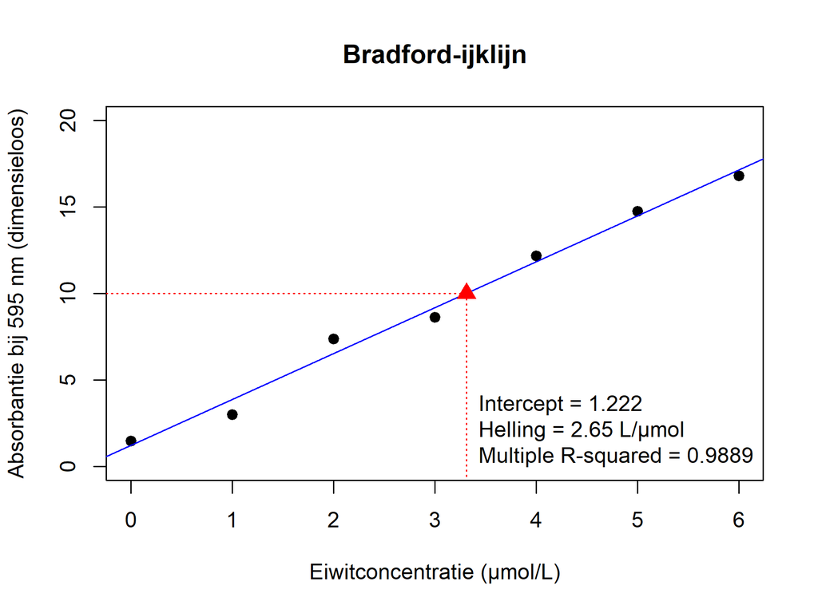

Het bestand `ijklijn.png` staat nu in je werkmap (die vind je met `getwd()`). In Word voeg je het in via *Invoegen* → *Afbeeldingen*.